# Reproducible Research: Peer Assessment 1

This is a data analysis developed by Angel Udias for the first assignment in the [Reproducible Research course of the Specialization in Data Science by Johns Hopkins University through Coursera]

## Loading and preprocessing the data

```r
PathCode<-"H:/CURSOS/COURSERA/SpecializationDataScience_JohnsHopkins/ReproducibleSearch/Peer_Assessment/PA1"
setwd (PathCode)
mydf <- read.table("./activity.csv",header=TRUE, sep = ',')
str(mydf)
```

```
## 'data.frame':    17568 obs. of  3 variables:
##  $ steps   : int  NA NA NA NA NA NA NA NA NA NA ...
##  $ date    : Factor w/ 61 levels "2012-10-01","2012-10-02",..: 1 1 1 1 1 1 1 1 1 1 ...
##  $ interval: int  0 5 10 15 20 25 30 35 40 45 ...
```

```r
head(mydf)
```

```
##   steps       date interval
## 1    NA 2012-10-01        0
## 2    NA 2012-10-01        5
## 3    NA 2012-10-01       10
## 4    NA 2012-10-01       15
## 5    NA 2012-10-01       20
## 6    NA 2012-10-01       25
```

```r
data <- read.csv("activity.csv", colClasses=c("integer", "Date", "factor"))
str(mydf)
```

```
## 'data.frame':    17568 obs. of  3 variables:
##  $ steps   : int  NA NA NA NA NA NA NA NA NA NA ...
##  $ date    : Factor w/ 61 levels "2012-10-01","2012-10-02",..: 1 1 1 1 1 1 1 1 1 1 ...
##  $ interval: int  0 5 10 15 20 25 30 35 40 45 ...
```

```r
#only the clean data
dataWithoutNA <- na.omit(data)
str(dataWithoutNA)
```

```
## 'data.frame':    15264 obs. of  3 variables:
##  $ steps   : int  0 0 0 0 0 0 0 0 0 0 ...
##  $ date    : Date, format: "2012-10-02" "2012-10-02" ...
##  $ interval: Factor w/ 288 levels "0","10","100",..: 1 226 2 73 136 195 198 209 212 223 ...
##  - attr(*, "na.action")=Class 'omit'  Named int [1:2304] 1 2 3 4 5 6 7 8 9 10 ...
##   .. ..- attr(*, "names")= chr [1:2304] "1" "2" "3" "4" ...
```

## The dataset

The variables included in this dataset are: * V1 (steps): Number of steps taking in a 5-minute interval (missing values are coded as NA) * V2 (date): The date on which the measurement was taken in YYYY-MM-DD format * V3 (interval): Identifier for the 5-minute interval in which measurement was taken The dataset is stored in a comma-separated-value (CSV) file and there are a total of 17568 observations in this dataset.

## What is mean total number of steps taken per day?

For this part, ignore the missing values in the dataset. * Make a histogram of the total number of steps taken each day

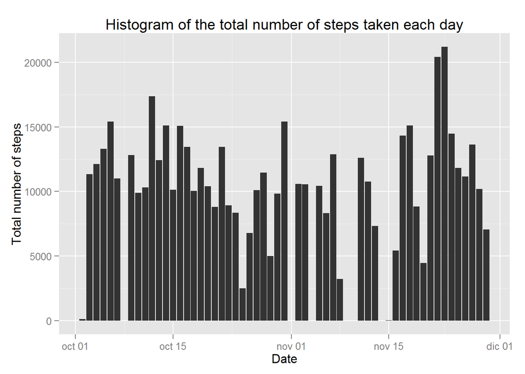

```r
ggplot(dataWithoutNA, aes(x = date, y = steps)) + geom_histogram(stat = "identity") +
labs(title="Histogram of the total number of steps taken each day",
x="Date", y="Total number of steps")
```

* Calculate and report the **mean** total number of steps taken per day

```r
totalStepsPerDay <- aggregate(dataWithoutNA$steps, list(Date = dataWithoutNA$date), sum)$x
mean(totalStepsPerDay)
```

```
## [1] 10766
```

- Calculate and report the **median** total number of steps taken per day

```r
median(totalStepsPerDay)
```

```
## [1] 10765
```

## What is the average daily activity pattern?

- Make a time series plot (i.e. type = “l”) of the 5-minute interval (x-axis) and the average number of steps taken, averaged across all days (y-axis)

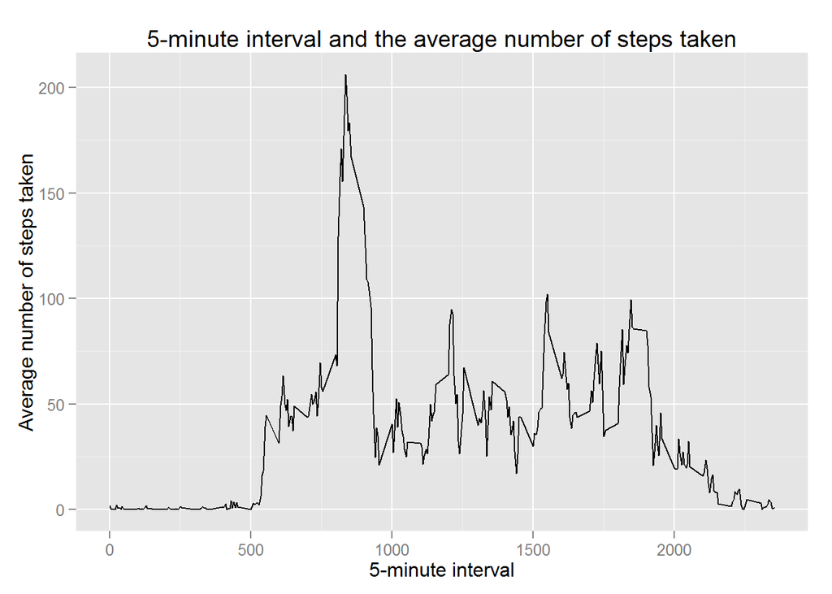

```r
averageStepsPerDay <- aggregate(dataWithoutNA$steps, list(Interval=as.numeric(as.character(dataWithoutNA$interval))), mean)
ggplot(averageStepsPerDay, aes(x=Interval, y=x)) + geom_line() +
labs(title="5-minute interval and the average number of steps taken",
x="5-minute interval", y="Average number of steps taken")
```

* Which 5-minute interval, on average across all the days in the dataset, contains the maximum number of steps?

```r
averageStepsPerDay[which.max(averageStepsPerDay$x), ]
```

```
##     Interval     x
## 104      835 206.2
```

## Imputing missing values

Note that there are a number of days/intervals where there are missing values (coded as NA). The presence of missing days may introduce bias into some calculations or summaries of the data. * Calculate and report the total number of missing values in the dataset (i.e. the total number of rows with NAs)

```r
nrow(data) - nrow(dataWithoutNA)
```

```
## [1] 2304
```

```r
for(i in 1:nrow(data)){
if (is.na(data$steps[i])){
data$steps[i] <- averageStepsPerDay[which(averageStepsPerDay$Interval == data$interval[i]), ]$x
}
}
head(data)
```

```
##     steps       date interval
## 1 1.71698 2012-10-01        0
## 2 0.33962 2012-10-01        5
## 3 0.13208 2012-10-01       10
## 4 0.15094 2012-10-01       15
## 5 0.07547 2012-10-01       20
## 6 2.09434 2012-10-01       25
```

- Make a histogram of the total number of steps taken each day and Calculate and report the **mean** and **median** total number of steps taken per day.

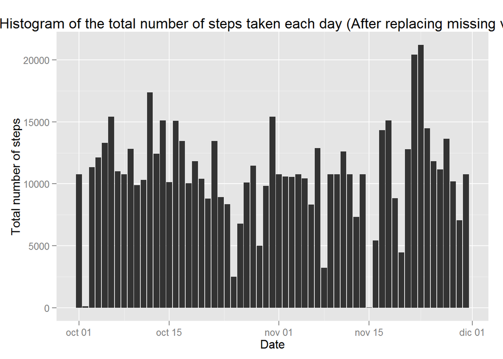

```r
ggplot(data, aes(x = date, y = steps)) + geom_histogram(stat = "identity") +
labs(title="Histogram of the total number of steps taken each day (After replacing missing values)",
x="Date", y="Total number of steps")
```

* Do these values differ from the estimates from the first part of the assignment? What is the impact of imputing missing data on the estimates of the total daily number of steps?

```r
totalStepsPerDayAfterImputing <- aggregate(data$steps, list(Date = data$date), sum)$x
meanMedian <- c(mean(totalStepsPerDay), median(totalStepsPerDay), mean(totalStepsPerDayAfterImputing), median(totalStepsPerDayAfterImputing))
meanMedianMatrix <- matrix(meanMedian,ncol=2,byrow=TRUE)
colnames(meanMedianMatrix) <- c("Mean","Median")
rownames(meanMedianMatrix) <- c("Before imputing","After imputing")
as.table(meanMedianMatrix)
```

```
##                  Mean Median
## Before imputing 10766  10765
## After imputing  10766  10766
```

```r
days <- mapvalues(weekdays(data$date, abbreviate=TRUE),
c("Mon", "Tue", "Wed", "Thu", "Fri", "Sat", "Sun"),
c(rep("weekday", 5), rep("weekend", 2)))
data$weekday <- factor(days)
table(data$weekday)
```

```
##
##  dom  jue  lun  mar  mié  sáb  vie
## 2304 2592 2592 2592 2592 2304 2592
```

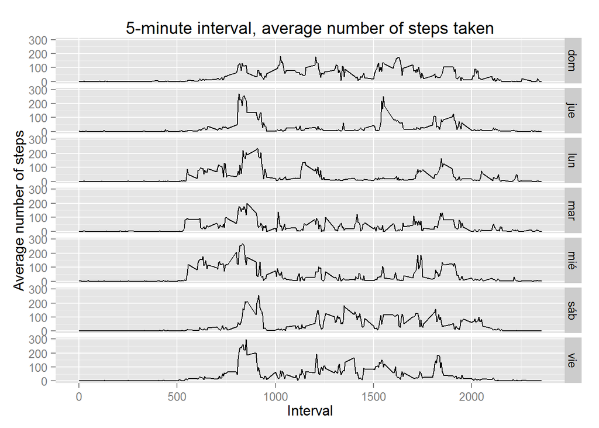

```r
averageStepsPerDay <- aggregate(data$steps, list(Interval=as.numeric(as.character(data$interval)), Weekday= data$weekday), mean)
ggplot(averageStepsPerDay, aes(x=Interval, y=x)) + geom_line() +
facet_grid(Weekday ~ .) +
labs(title="5-minute interval, average number of steps taken",
x="Interval", y="Average number of steps")
```